# PetFinder.my Adoption prediction

[figure not shown]

## Udacity Data Science nano-degree capstone project

### Project overview

The project was taken from a [kaggle competition](https://www.kaggle.com/c/petfinder-adoption-prediction). To summarize the idea: We want to improve abandoned animals welfare (especially dogs/cats) by quicker adoption. PetFinder.my has been Malaysia’s leading animal welfare platform since 2008, with a database of more than 150,000 animals. Animal adoption rates are strongly correlated to the metadata associated with their online profiles, such as descriptive text and photo characteristics. The beauty in the project is that it's well formulated, contains lots of various data types (thus allows to practice many aspects of the course) and is a real life problem.

### Problem Statement

Develop an alogrithm that ranks the adoptability of pets - specifically, **how quickly is a pet adopted**? This is a multiclass classification problem with 5 classes: (Although it can also be considered a regression problem)

- 0 - Pet was adopted on the same day as it was listed.
- 1 - Pet was adopted between 1 and 7 days (1st week) after being listed.
- 2 - Pet was adopted between 8 and 30 days (1st month) after being listed.
- 3 - Pet was adopted between 31 and 90 days (2nd & 3rd month) after being listed.
- 4 - No adoption after 100 days of being listed. (There are no pets in this dataset that waited between 90 and 100 days).

#### Strategy for solving the problem

In my mind and with the knowledge from this course and Coursera deep learning specialization.

### Metrics

The competition metric is the **quadratic weighted kappa (qwk)**, which measures the agreement between two ratings. I wasn't familiar with it prior to this exercise. A nice explanation can be found [here](https://stats.stackexchange.com/questions/248583/quadratic-weighted-kappa) or [here](https://en.wikipedia.org/wiki/Cohen%27s_kappa#Weighted_kappa). Why is it justified? Accuracy could have been a good metric because by definition we're interested in accurate predictions and we're not very afraid of FN or FP (Perhaps then we'd like to use precision/recall as metrics). The **qwk** is similar to accuracy but also attempts to consider the number of accurate predictions that were derived by **chance**.

```python
# Imports
import pandas as pd
import numpy as np
import os
import seaborn as sns
import matplotlib
import matplotlib.pyplot as plt
from Utils import ETL_pipeline, ETL_pipeline_ver2, \
FindBestClfGridSearch, GetImageFeaturesForAllPetIds, GetImageMetaData, PlotImportances

# Cohen Kappa score metric exists in sklearn. See discussion here:
# https://www.kaggle.com/aroraaman/quadratic-kappa-metric-explained-in-5-simple-steps
from sklearn.metrics import cohen_kappa_score
from sklearn.metrics import make_scorer

# Set display options in Jupyter
pd.set_option('display.max_rows', 500)
pd.set_option('display.max_columns', 500)
pd.set_option('display.width', 1000)
```

### Data Exploration

In this section we'll explore the data a bit, get some insights about it, we begin with general statistics and data related to missing/unspecified values.

```python
# Get data frame
filename = 'train.csv'
df = pd.read_csv(os.getcwd() + os.sep + 'Data' + os.sep + filename)

# Show data example
df.head(2)
```

|  | Type | Name | Age | Breed1 | Breed2 | Gender | Color1 | Color2 | Color3 | MaturitySize | FurLength | Vaccinated | Dewormed | Sterilized | Health | Quantity | Fee | State | RescuerID | VideoAmt | Description | PetID | PhotoAmt | AdoptionSpeed |
| --- | --- | --- | --- | --- | --- | --- | --- | --- | --- | --- | --- | --- | --- | --- | --- | --- | --- | --- | --- | --- | --- | --- | --- | --- |
| 0 | 2 | Nibble | 3 | 299 | 0 | 1 | 1 | 7 | 0 | 1 | 1 | 2 | 2 | 2 | 1 | 1 | 100 | 41326 | 8480853f516546f6cf33aa88cd76c379 | 0 | Nibble is a 3+ month old ball of cuteness. He ... | 86e1089a3 | 1.0 | 2 |
| 1 | 2 | No Name Yet | 1 | 265 | 0 | 1 | 1 | 2 | 0 | 2 | 2 | 3 | 3 | 3 | 1 | 1 | 0 | 41401 | 3082c7125d8fb66f7dd4bff4192c8b14 | 0 | I just found it alone yesterday near my apartm... | 6296e909a | 2.0 | 0 |

```python
# Calcualte some statistics:
print('Total of %d listings in data and %d columns' % (df.shape[0], df.shape[1]))
print('Num of dogs: %d, (%2.2f%% of data)' % (df['Type'].value_counts()[1], 100*df['Type'].value_counts()[1]/df.shape[0]))
print('Num of cats: %d, (%2.2f%% of data)' % (df['Type'].value_counts()[2], 100*df['Type'].value_counts()[2]/df.shape[0]))
print('\nAdoption speeds distribution:\n%s\n' % (df['AdoptionSpeed'].value_counts()))

# How many animals per state?
index_list = df['State'].value_counts().index.tolist() # Create indices of states (StateID)
values_list = df['State'].value_counts().values.tolist() # How many animals per state
state_labels_df = pd.read_csv(os.getcwd() + os.sep + 'Data' + os.sep + 'state_labels.csv') # Load the state labels data
states_dict = state_labels_df.set_index('StateID').to_dict()['StateName'] # Generate StateID<-->Name dictionary
q = 0;
for state in index_list:
    print('State: %s, Animals: %d' % (states_dict[state], values_list[q]))
    q += 1

# Analyze missing values
print('\nColumns with missing values (and how much):\n%s\n' % (df.isnull().sum()[df.isnull().sum() > 0]))

# For the the fields with "unsure/unknown"
print('Num of listings with UNSPECIFIED fur length: %d (%2.2f%%)' %
      (df[df['FurLength'] == 0].shape[0], 100*df[df['FurLength'] == 0].shape[0]/df.shape[0]))
print('Num of listings with NOT SURE vaccination: %d (%2.2f%%)' %
      (df[df['Vaccinated'] == 3].shape[0], 100*df[df['Vaccinated'] == 3].shape[0]/df.shape[0]))
print('Num of listings with NOT SURE dewormed: %d (%2.2f%%)' %
      (df[df['Dewormed'] == 3].shape[0], 100*df[df['Dewormed'] == 3].shape[0]/df.shape[0]))
print('Num of listings with NOT SURE Sterilized: %d (%2.2f%%)' %
      (df[df['Sterilized'] == 3].shape[0], 100*df[df['Sterilized'] == 3].shape[0]/df.shape[0]))
print('Num of listings with NOT Specified Health: %d (%2.2f%%)\n' %
      (df[df['Health'] == 0].shape[0], 100*df[df['Health'] == 0].shape[0]/df.shape[0]))

# - How many have sentiments?
petIds = set(df['PetID'].values.tolist())
path = os.getcwd() + os.sep + 'Data' + os.sep + 'train_sentiment'
filesList = os.listdir(path)
filesList = set( [word.split('.')[0] for word in filesList] )
num_no_listings = len(petIds) - len(petIds.intersection(filesList))
print('%d (%2.2f%%) have NO sentiment analysis\n' % (num_no_listings, 100*num_no_listings/df.shape[0]))

# How many have movies/photos?
num_listings_photo = df[df['PhotoAmt'] > 0].shape[0]
num_listings_video = df[df['VideoAmt'] > 0].shape[0]
print('%d (%2.2f%%) listings have photos' % (num_listings_photo, 100*num_listings_photo/df.shape[0]))
print('%d (%2.2f%%) listings have videos\n' % (num_listings_video, 100*num_listings_video/df.shape[0]))

# Check for duplicates
tmp = df.duplicated(subset=None, keep=False )
res = (tmp.head() == True).sum()
if (res == 0):
    print('NO DUPLICATES FOUND\n')
else:
    print('DUPLICATES FOUND\n')

# How many listings have more than one pet inside?
L = df[df['Quantity'] > 1].shape[0]
print('Listings with more than one pet: %d (%2.2f%%)' % (L, 100*L/df.shape[0]))
```

```
Total of 14993 listings in data and 24 columns
Num of dogs: 8132, (54.24% of data)
Num of cats: 6861, (45.76% of data)

Adoption speeds distribution:
4    4197
2    4037
3    3259
1    3090
0     410
Name: AdoptionSpeed, dtype: int64

State: Selangor, Animals: 8714
State: Kuala Lumpur, Animals: 3845
State: Pulau Pinang, Animals: 843
State: Johor, Animals: 507
State: Perak, Animals: 420
State: Negeri Sembilan, Animals: 253
State: Melaka, Animals: 137
State: Kedah, Animals: 110
State: Pahang, Animals: 85
State: Terengganu, Animals: 26
State: Sabah, Animals: 22
State: Kelantan, Animals: 15
State: Sarawak, Animals: 13
State: Labuan, Animals: 3

Columns with missing values (and how much):
Name           1257
Description      12
dtype: int64

Num of listings with UNSPECIFIED fur length: 0 (0.00%)
Num of listings with NOT SURE vaccination: 1868 (12.46%)
Num of listings with NOT SURE dewormed: 1781 (11.88%)
Num of listings with NOT SURE Sterilized: 1815 (12.11%)
Num of listings with NOT Specified Health: 0 (0.00%)

551 (3.68%) have NO sentiment analysis

14652 (97.73%) listings have photos
574 (3.83%) listings have videos

NO DUPLICATES FOUND

Listings with more than one pet: 3428 (22.86%)
```

I'll now add some more visualizations describing the data:

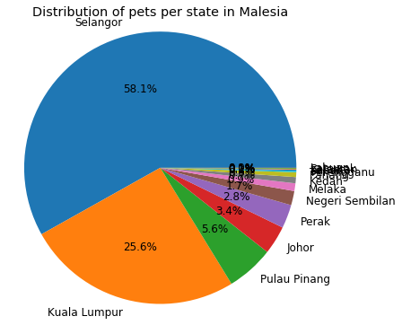

```python
# Plot distribution of pets per state
num_pets_per_state = df['State'].value_counts().values.tolist()
state_names = [states_dict[x] for x in df['State'].value_counts().index.values.tolist()]

N=7
fontsize = 12
matplotlib.rcParams.update({'font.size': fontsize})
fig, ax = plt.subplots(figsize=(6,6))
ax.pie(num_pets_per_state, labels=state_names, autopct='%1.1f%%' )
ax.axis('equal')  # Equal aspect ratio ensures that pie is drawn as a circle.
plt.title('Distribution of pets per state in Malesia')
```

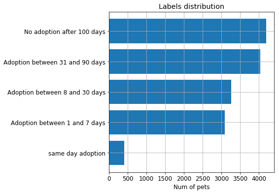

```python
# Plot labels types distribution - Clearly shows the imbalanced labels.
y = df['AdoptionSpeed'].value_counts().values.tolist()[::-1]
x = ['same day adoption', 'Adoption between 1 and 7 days', 'Adoption between 8 and 30 days', \
     'Adoption between 31 and 90 days','No adoption after 100 days']

fig, ax = plt.subplots(figsize=(6,6))
plt.barh(x, y)
plt.xlabel('Num of pets')
plt.title('Labels distribution')
plt.grid()
```

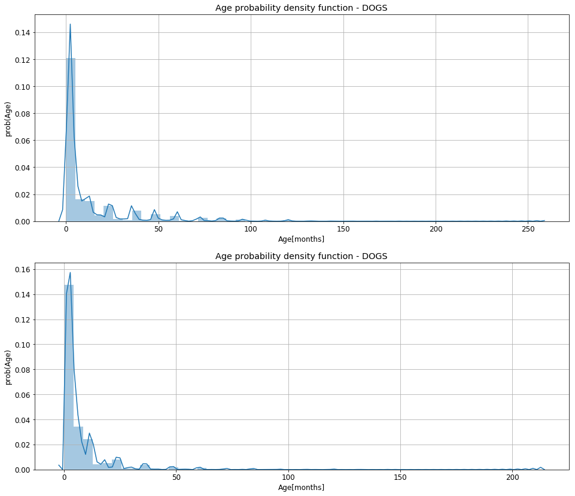

```python
# It would also be interesting to know what's the distribution of ages in the repository (Cats/Dogs)

fig, ax = plt.subplots(figsize=(16,14))
plt.subplot(2,1,1)
ax = sns.distplot(df[df['Type'] == 1]['Age'].values.tolist())
plt.grid()
plt.title('Age probability density function - DOGS')
plt.ylabel('prob(Age)')
plt.xlabel('Age[months]')

plt.subplot(2,1,2)
ax = sns.distplot(df[df['Type'] == 2]['Age'].values.tolist())
plt.grid()
plt.ylabel('prob(Age)')
plt.title('Age probability density function - DOGS')
plt.xlabel('Age[months]')
```

### Data Exploration (cnt.)

From the exploration above, we see that for the training data we have:

- Slight imbalance between dogs cats (approx. 45/55 split)
- Imbalanced labels, specifically, low number of pets adopted on the 1st day. ("Ideal scenario")
- Approximately 93% of pets in data are from 4 (out of 14) states in Malesia.
- Neglecting the name (which I don't think is relevant), there are only 12 missing descriptions. (negligble).
- For about 12% of animals we're unsure about their vaccination/dewormed/sterlized status.
- Some listings (small fraction) don't have a Google sentiment analysis.
- Most listings have photos but only a fraction have videos.
- There are no duplicated values.
- A LOT of listings contain more than one pet!
- From the age distribution we see that it's similar between dogs/cats. Also, most dogs are young (< 2years)

So, to summarize, in terms of the ETL pipeline, the "abnormalities" we'll have to deal with are:

- Some columns which I don't see any use of (Name, RescuerID, ...) which I'll drop.
- few missing descriptions. (Don't care about names).
- Some missing sentiments.
- If photo raw data is required, some missing photos.
- Imbalances in labels. (Will impact training).
- **I DO NOT ENCODE CATEGORICAL VARIABLES** because they're already in numerical format, and I plan to use a tree based classifier so one-hot encoding isn't recommended. (see [here](https://medium.com/data-design/visiting-categorical-features-and-encoding-in-decision-trees-53400fa65931))
- Imbalances between number of dogs/cats in database (More on that later).
- Imbalances between number of pets per state.
- Listings with multiple pets. (Not sure yet how to approach this...)

**We now continue exploring relations between parameters and adoption speed (to get a feeling) regarding what will affect the adoption speed**

NOTE: according to the following [kernel](https://www.kaggle.com/conradws/don-t-put-cats-and-dogs-in-the-same-teapot) You can see that it's recommended to separate the dogs/cats classifications. This also follows my intuition, since (as a dog owner myself) I think people are looking for different things between dogs and cats.

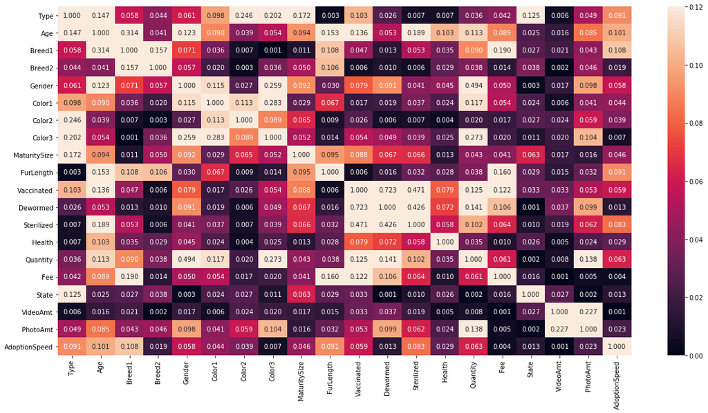

```python
# First I want to examine the correlations in the data
fig, ax = plt.subplots(figsize=(20,10))
sns.heatmap(np.abs(df.corr()), annot=True, fmt=".3f", ax=ax, vmin=0, vmax=0.12)
```

We observe some forseeable facts (vaccination/deworming and sterlization are all corellated, and also the fee. Makes sense. Money was spent on a "treated" pet so a fee is required. We can also see physical pet traits (Maturity size is related to gender. Probably males are bigger). However, all of this is nice. We want to focus on the Adoption speed correlation to the original columns. (Later we're going to add other columns...)

**NOTICE: Some correlations aren't very useful, because their categorical variables don't have any meaninfgul ordering. For example, Breed/Colors. The "higher" the "breed" goes, what's the impact on adoption speed? It's nonsense, so we need to disregard these fields.. Other fields have some ordinal meaning, for example, "Vaccinated: 1 = Yes, 2 = No, 3 = Not Sure", so, "higher value" means non vaccinated or "unsure" status. However, again, this is a rough approximation**

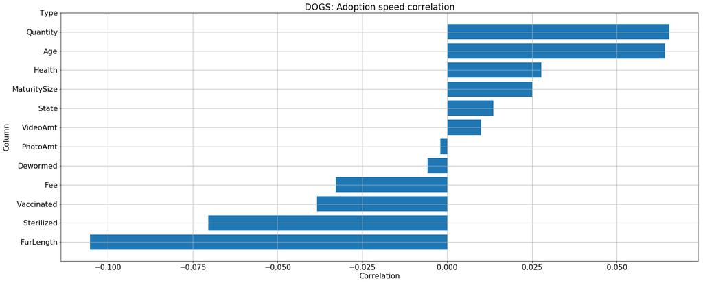

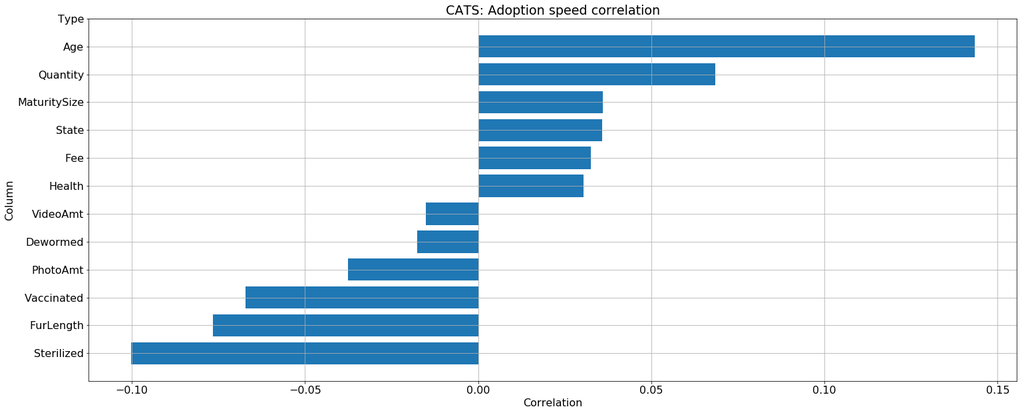

```python
# Plot the Adoption speed correlation to other columns, seperating for dogs/cats
fontsize = 16
matplotlib.rcParams.update({'font.size': fontsize})
types = [1,2]
cols_to_remove = ['Breed1','Breed2','Color1','Color2','Color3', 'Gender']
tmp_df = df.drop(cols_to_remove, axis=1)
for petType in types:
    x = tmp_df[tmp_df['Type'] == petType].corr()['AdoptionSpeed'].sort_values().index.values.tolist()
    y = tmp_df[tmp_df['Type'] == petType].corr()['AdoptionSpeed'].sort_values().values.tolist()
    x.remove('AdoptionSpeed')
    y.remove(1.0)

    fig, ax = plt.subplots(figsize=(25,10))
    plt.barh(x,y)
    if petType == 1:
        plt.title('DOGS: Adoption speed correlation')
    else:
        plt.title('CATS: Adoption speed correlation')

    plt.grid(True)
    plt.xlabel('Correlation', fontsize = fontsize)
    plt.ylabel('Column',  fontsize = fontsize)
```

### Analysis

We see 2 trends:

- 1st, dogs and cats behave DIFFERENTLY, regarding what "features" impact the adoption speed. This agrees with the kaggle kernel discussed previously.
- The most influencing ORIGINAL features (later, we'll generate more features) are:

  For dogs:
  - Age (Positive correlation. Older (higher value of age) dogs are waiting more for adoption)
  - Quantity (Positive correlation. The more dogs the longer it takes to adopt)
  - Fur length (Negative correlation. The more fur (higher value) the quicker (lower value) dogs get adopted).
  - Sterilization (Negative correlation. The "higer" the value (not sterlized or unsure) the quicker dogs are adopted)

  For cats:
  - Same relations with age and quantity as dogs.
  - Similar relations to dogs with sterilization and fur length, but for cats, sterilization (specifically, no sterlization) correlates more to faster adoption.

In general:

- It seems that the dominant features correlating to adoption speed are very similar between cats and dogs, even though the correlation values are different.
- It seems that the **amount** of photos/videos isn't strongly related to adoption speeds which is good. I think that later on, adding a NN that extracts feature images might help, that is to say, I believe the **content** of the images may help.
- As an example, I'll also plot the "distribution" of adoption speed vs. fur length. We expect to see lower adoption values for higher fur values.

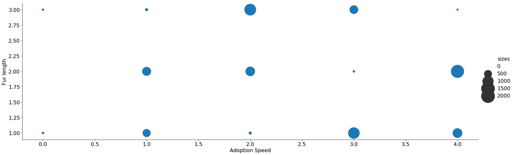

```python
## Show "distribution" of adoption speeds vs fur length

# Init
sizes, furlen, adspeed = [], [1,2,3], [0,1,2,3,4]
x = adspeed * len(furlen) # Trick to generate a meshgrid
y = furlen * len(adspeed) # Trick to generate a meshgrid

# Extract data for dogs
tmp = df[df['Type'] == 1][['FurLength','AdoptionSpeed']]

# Count how many values in each group. Probably there's a better "Pandas" way to do it
for f in furlen:
    tmp2 = tmp[tmp['FurLength'] == f]
    for a in adspeed:
        tmp3 = tmp2[tmp2['AdoptionSpeed'] == a]
        sizes.append(tmp3.shape[0])

# Generate dataframe from meshgrid and sizes
tmp = pd.DataFrame({'Fur length':y, 'Adoption Speed':x, 'sizes': sizes})

# Plot
g = sns.relplot(y='Fur length',x='Adoption Speed', size='sizes', sizes=(0, 1700), palette="muted",data=tmp,
               aspect = 3, height = 7)
```

### Analysis

It's not that obvious, but we can see that there's a concentration of values in the lower right side (short fur, long time for adoption) and a concentration in the middle upper part (medium to long fur, shorter adoption times). This supports our earlier correlation findings.

**Summary: I can add many more plots, but I think these ones + the tabular data are sufficent to CONCISELY describe the relations between parameters and the data. The interested reader may see many more data explorations [here](https://www.kaggle.com/artgor/exploration-of-data-step-by-step)**.

## Processing

- We start iterations for classifiers and their performance.
- I did MANY iterations. For readbility, some stages I experimented with are NOT inside the notebook and will only be briefly discussed.
- All the "heavy lifting" of the code is done behind the scenes in the Utils.py file, so, please review it.
- Also, I utilized grid search in order to optimize hyperparaemetrs. In order to reduce runtimes, all the parameters here are already the best I've found (So it's a gridsearch with only "1 point" of search, but believe me, it was optimized previously).

What is the current processing stage doing (in a nutshell):

**NOTICE** A stage not appearing in the notebook is doing the same but with NLP mode "off". This means data had no extra features extracted from the description field in the dataframe.

```python
# Run the ETL pipeline for getting dataframes for dogs/cats
df_dogs, df_cats, labels_dogs, labels_cats = ETL_pipeline('train.csv',0, True, True)
```

```python
# Define Scorer and cross validation fold counts + parameters for tests
best_params_lgb = {'application': ['classification'], 'boosting': ['gbdt'], 'num_leaves': [100],
                   'max_depth': [15], 'learning_rate': [0.1], 'bagging_fraction': [0.85], 'feature_fraction': [0.8],
                   'min_split_gain': [0.02], 'min_child_samples': [150], 'min_child_weight': [0.02],
                   'verbosity': [-1], 'data_random_seed': [17], 'verbose_eval': [100]}

scorer, cv = make_scorer(cohen_kappa_score, weights='quadratic'), 5
```

```
Fitting 5 folds for each of 1 candidates, totalling 5 fits
```

```
[Parallel(n_jobs=1)]: Using backend SequentialBackend with 1 concurrent workers.
[Parallel(n_jobs=1)]: Done   5 out of   5 | elapsed:    2.9s finished
```

```
Best parameters set found on development set:
{'application': 'classification', 'bagging_fraction': 0.85, 'boosting': 'gbdt', 'data_random_seed': 17, 'feature_fraction': 0.8, 'learning_rate': 0.1, 'max_depth': 15, 'min_child_samples': 150, 'min_child_weight': 0.02, 'min_split_gain': 0.02, 'num_leaves': 100, 'verbose_eval': 100, 'verbosity': -1}
#### Test set cohen_kappa: 0.41652 ####
```

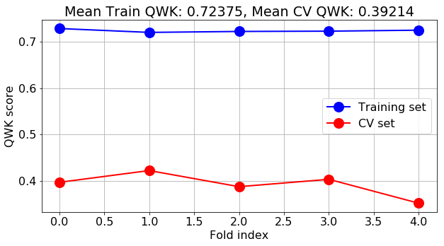

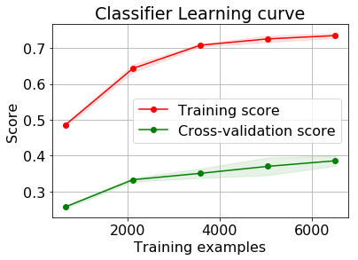

```python
# Test Dogs Classifier
X = df_dogs.drop('PetID', axis=1)
y = labels_dogs['AdoptionSpeed']
clf = FindBestClfGridSearch(best_params_lgb, X, y, scorer, cv, clf_type = 'lgb', plot_learning_curve = True)
```

```
Fitting 5 folds for each of 1 candidates, totalling 5 fits
```

```
[Parallel(n_jobs=1)]: Using backend SequentialBackend with 1 concurrent workers.
[Parallel(n_jobs=1)]: Done   5 out of   5 | elapsed:    2.3s finished
```

```
Best parameters set found on development set:
{'application': 'classification', 'bagging_fraction': 0.85, 'boosting': 'gbdt', 'data_random_seed': 17, 'feature_fraction': 0.8, 'learning_rate': 0.1, 'max_depth': 15, 'min_child_samples': 150, 'min_child_weight': 0.02, 'min_split_gain': 0.02, 'num_leaves': 100, 'verbose_eval': 100, 'verbosity': -1}
#### Test set cohen_kappa: 0.34137 ####
```

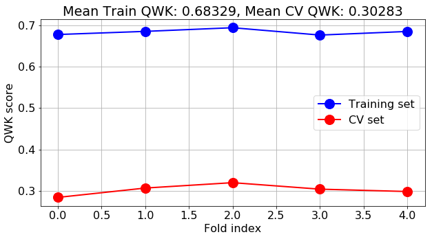

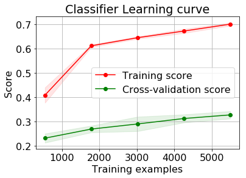

```python
# Test Cats Classifier
X = df_cats.drop('PetID', axis=1)
y = labels_cats['AdoptionSpeed']
clf = FindBestClfGridSearch(best_params_lgb, X, y, scorer, cv, clf_type = 'lgb', plot_learning_curve = True)
```

```
Fitting 5 folds for each of 1 candidates, totalling 5 fits
```

```
[Parallel(n_jobs=1)]: Using backend SequentialBackend with 1 concurrent workers.
[Parallel(n_jobs=1)]: Done   5 out of   5 | elapsed:    5.2s finished
```

```
Best parameters set found on development set:
{'application': 'classification', 'bagging_fraction': 0.85, 'boosting': 'gbdt', 'data_random_seed': 17, 'feature_fraction': 0.8, 'learning_rate': 0.1, 'max_depth': 15, 'min_child_samples': 150, 'min_child_weight': 0.02, 'min_split_gain': 0.02, 'num_leaves': 100, 'verbose_eval': 100, 'verbosity': -1}
#### Test set cohen_kappa: 0.37574 ####
```

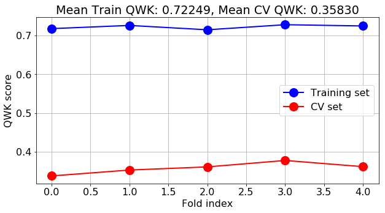

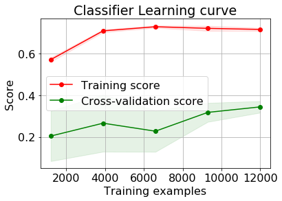

```python
# Test both dogs and cats
# Combine data
df_combined = pd.concat( [df_dogs, df_cats], axis = 0 )
labels_combined = pd.concat( [labels_dogs, labels_cats], axis = 0 )

# Start analysis with dogs
X = df_combined.drop('PetID', axis=1)
y = labels_combined['AdoptionSpeed']
clf, X_test, y_test = FindBestClfGridSearch(best_params_lgb, X, y, scorer, cv, clf_type = 'lgb', plot_learning_curve = True)
```

### Background

1. Reminder (Ensemble methods): These methods can be divided to either bagging or boosting. Obviously, (by the name), we're talking about boosting. Short reminder: Boosting is a method that has multiple weak learners that are improved sequentially. Each learner cost function gets "punished" (increased weights) on the misclassified points of the previous learner and thus is "boosted".
2. [Gradient Boosting](https://en.wikipedia.org/wiki/Gradient_boosting): GBM wasn't learned in the current course. It's an ensemble method of boosting. In simple terms:
   - Define $x$ the parameter we want to etimate.
   - at stage 'n', our estimator is a function of 'x', e.g. $F_n(x)=y_{estimated}$.
   - Ideally, we would like to have an $h(x)$ function such that $F_{n+1}(x)=y_{true}=F_n(x)+h(x)$
   - In other words: $h(x)=y_{true}-F_n(x)$
   - Notice that if we have a squared error loss $0.5(y-F_n(x))^2$, $h(x)$ is the gradient!

Therefore, gradient boosting will fit $h$ to the residual $y-F_n(x)$, and by "fitting" I mean it will try to find an approximation that will minimize the average value of the loss function on the training set. (An approximation can be some curve for a polynomial regression problem, for example).

1. [XGBoost](https://arxiv.org/pdf/1603.02754.pdf) is an "extreme" version of Gradient Boosting. It can run over parallel processors and even on parallel machines (such as clusters in the cloud...). **LightGBM** (My preferred method) is similar in performance but runs faster.
1. **NLP**: Some more elaboration here... I implemented 2 NLP methods as part of the ETL pipeline. They are used for conversion of the "description" field. One method uses word embeddings, and converts the words of the description to 300 elements vectors from a pruned corpus originally generated by Google. The representation is the averaged vector of all words. The 2nd option (which I chose to use) is generating a TF-IDF bag of words from all descriptions and vectorizing the descriptions. For both methods I reduced the dimensionality (after testing it) via [SVD](https://en.wikipedia.org/wiki/Latent_semantic_analysis) because the LightGBM/XGBoost tend to overfit (We get a very high training score but still not good CV result)

### Analysis

- I created 3 initial **LightGBM** models. One for cats, one for dogs and one for both. Their performance differs. It seems that the dog classifer is much better than the cat classifier, and that the combined classifier is an average between the two.
- It was very important for me to plot the learning curves. From them, We notice 2 trends:
  - Training QWK increases (Error is reduced) the more samples we have.
  - CV QWK increasing (Error is reduced) the more samples we have.

Using this I conclude that my training is still overfitting the data because there's a large gap between training and CV performance.

The summary of the results is:

| Score | Dogs only | Cats only | Combined |
| --- | --- | --- | --- |
| Train | 0.72 | 0.68 | 0.72 |
| CV | 0.39 | 0.3 | 0.358 |

### Moving forward:

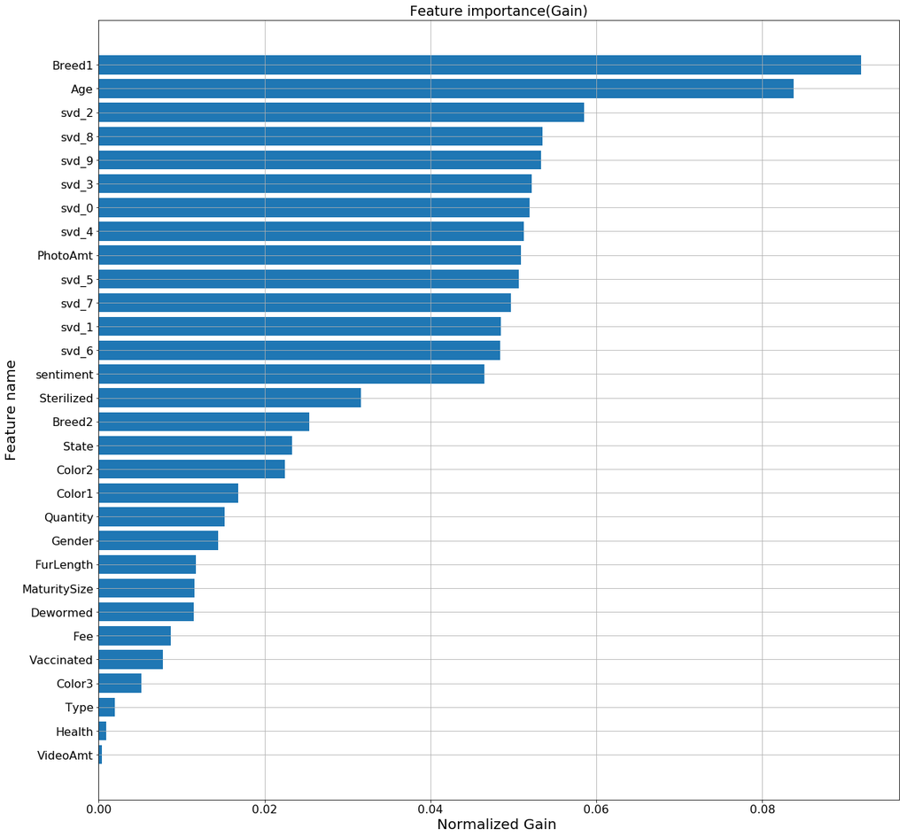

```python
PlotImportances(df_combined, clf, 'gain')
```

### Feature importances

**Bottom line**: **There is some matching between correlations and feature importances, but not too much...**. Some features we didn't check because there's no meaning to correlation for numerical encoding of them (dog breeds, for example) however, they might be important. Example: 'Breed1'.

### Moving forward

Let's attempt to get some insight from our erros...

```python
# Some analysis of failed results for cats.. Can we see something interesting?
# 1. The magnitude of errors distribution
clf = clf.best_estimator_
y_pred = clf.predict(X_test)
tmp = abs(y_pred-y_test)
num_errors = tmp[tmp.values > 0].shape[0]
err_list = (tmp[tmp.values > 0].value_counts().values/num_errors*100).tolist()
for i in range(1,5):
    print('%2.2f%% of prediction errors miss by %d' % (err_list[i-1], i))

##### We see that ~80% of errors miss prediction by 1 or 2 time units #####
research_df = df_combined.loc[tmp[tmp.values > 0].index.values.tolist()]
print(research_df['Breed1'].value_counts().head(20))
print(research_df['Type'].value_counts())
```

```
56.84% of prediction errors miss by 1
29.66% of prediction errors miss by 2
11.97% of prediction errors miss by 3
1.53% of prediction errors miss by 4
307    626
266    405
265    177
299     44
264     31
292     30
205     29
285     28
179     22
141     21
218     20
103     17
109     15
195     12
283     11
152     10
20      10
254      9
60       9
247      9
Name: Breed1, dtype: int64
1    885
2    811
Name: Type, dtype: int64
```

### Refinements:

1. Attempt 1: Simplify model by removing "less important" columns.
2. Attempt 2: A lot of errors are around Breed. I'll add one hot columns for the 1st 4 most problematic breeds and see if it has any impact on the classification.

```python
df, labels = ETL_pipeline_ver2('train.csv',0, True, True)
```

```
Fitting 5 folds for each of 1 candidates, totalling 5 fits
```

```
[Parallel(n_jobs=1)]: Using backend SequentialBackend with 1 concurrent workers.
[Parallel(n_jobs=1)]: Done   5 out of   5 | elapsed:    4.8s finished
```

```
Best parameters set found on development set:
{'application': 'classification', 'bagging_fraction': 0.85, 'boosting': 'gbdt', 'data_random_seed': 17, 'feature_fraction': 0.8, 'learning_rate': 0.1, 'max_depth': 15, 'min_child_samples': 150, 'min_child_weight': 0.02, 'min_split_gain': 0.02, 'num_leaves': 100, 'verbose_eval': 100, 'verbosity': -1}
#### Test set cohen_kappa: 0.39277 ####
```

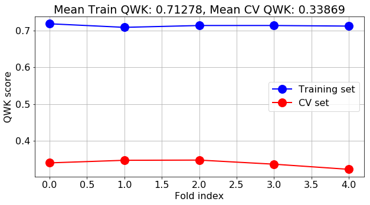

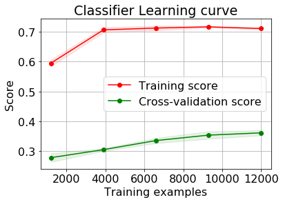

```python
# Remove data
cols_to_remove = ['VideoAmt', 'Fee', 'Color3','Type','Health']
df_simple = df.drop(columns = cols_to_remove)

# Start analysis with dogs
X = df_simple.drop('PetID', axis=1)
y = labels['AdoptionSpeed']

# Run test
combined_clf, X_test, y_test = FindBestClfGridSearch(best_params_lgb, X, y, scorer, cv, clf_type = 'lgb', plot_learning_curve = True)
```

**Unfortunately, results are worse than before...** I'll now attempt to test adding one hot indicator columns that indicate a "problematic" breed from the errors perspective we found earlier...

```
Fitting 5 folds for each of 1 candidates, totalling 5 fits
```

```
[Parallel(n_jobs=1)]: Using backend SequentialBackend with 1 concurrent workers.
[Parallel(n_jobs=1)]: Done   5 out of   5 | elapsed:    5.2s finished
```

```
Best parameters set found on development set:
{'application': 'classification', 'bagging_fraction': 0.85, 'boosting': 'gbdt', 'data_random_seed': 17, 'feature_fraction': 0.8, 'learning_rate': 0.1, 'max_depth': 15, 'min_child_samples': 150, 'min_child_weight': 0.02, 'min_split_gain': 0.02, 'num_leaves': 100, 'verbose_eval': 100, 'verbosity': -1}
#### Test set cohen_kappa: 0.40488 ####
```

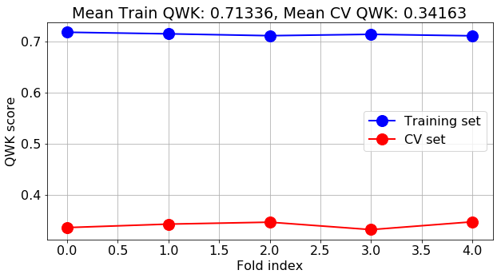

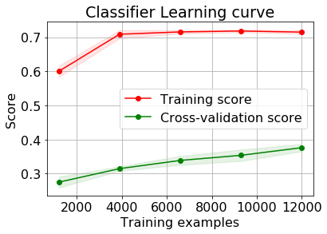

```python
# Create one hot encodings for breeds of specific type and add to simple/regular data, test best results
l=df_simple.shape[0]
one_hot_breed_307 = (df_simple['Breed1'].values == 307).astype(int).reshape((l,1))
one_hot_breed_266 = (df_simple['Breed1'].values == 266).astype(int).reshape((l,1))
one_hot_breed_265 = (df_simple['Breed1'].values == 265).astype(int).reshape((l,1))
one_hot_breed_299 = (df_simple['Breed1'].values == 299).astype(int).reshape((l,1))
tmp = np.concatenate((one_hot_breed_307, one_hot_breed_266, one_hot_breed_265, one_hot_breed_299), axis=1)

extra = pd.DataFrame(data = tmp, columns=['e1','e2','e3','e4'])
extra.set_index(df_simple.index.values, inplace=True, verify_integrity=False)
df_simple2 = pd.concat( [df, extra], axis=1)

# Start analysis with dogs
X = df_simple2.drop('PetID', axis=1)
y = labels['AdoptionSpeed']

# Run test
combined_clf, X_test, y_test = FindBestClfGridSearch(best_params_lgb, X, y, scorer, cv, clf_type = 'lgb', plot_learning_curve = True)
```